# Week 12 Assignment Graph Databases

John K. Hancock

November 19, 2018

## DATA 607 Fall 2018 - Week 12 Assignment

### Objective

Take information from a relational database created in week two’s assignment and migrate it to a MongoDB NoSQL database using R.

### 1. Practice with the MongoDB Tutorial

For this step, I installed the MongoDB database (community edition).

[Mongo Tutorial](https://docs.mongodb.com/manual/installation/)

```r
library(rmongodb)
# connect to MongoDB
mongo = mongo.create(host = "localhost")
print(mongo.is.connected(mongo))
```

```
## [1] TRUE
```

```r
#Read in the Chicago crimes dataset
crimes=data.table::fread("Chicago Homicides 2018.csv")
names(crimes)
```

```
##  [1] "ID"                   "Case Number"          "Date"
##  [4] "Block"                "IUCR"                 "Primary Type"
##  [7] "Description"          "Location Description" "Arrest"
## [10] "Domestic"             "Beat"                 "District"
## [13] "Ward"                 "Community Area"       "FBI Code"
## [16] "X Coordinate"         "Y Coordinate"         "Year"
## [19] "Updated On"           "Latitude"             "Longitude"
## [22] "Location"
```

```r
#Clean the data
names(crimes) = gsub(" ","",names(crimes))
names(crimes)
```

```
##  [1] "ID"                  "CaseNumber"          "Date"
##  [4] "Block"               "IUCR"                "PrimaryType"
##  [7] "Description"         "LocationDescription" "Arrest"
## [10] "Domestic"            "Beat"                "District"
## [13] "Ward"                "CommunityArea"       "FBICode"
## [16] "XCoordinate"         "YCoordinate"         "Year"
## [19] "UpdatedOn"           "Latitude"            "Longitude"
## [22] "Location"
```

```r
#Create a database and collection called crimes
my_collection = mongo(collection = "crimes", db = "Chicago") # create connection, database and collection
my_collection$insert(crimes)
```

```
## List of 5
##  $ nInserted  : num 424
##  $ nMatched   : num 0
##  $ nRemoved   : num 0
##  $ nUpserted  : num 0
##  $ writeErrors: list()
```

```r
#Take a look at the information
my_collection$info()
```

[output not shown]

```r
#Take a count of the collection
my_collection$count()
```

```
## [1] 848
```

```r
#Iterate over one table in the database
my_collection$iterate()$one()
```

```
## $ID
## [1] 23810
##
## $CaseNumber
## [1] "JB140548"
##
## $Date
## [1] "02/04/2018 01:36:00 AM"
##
## $Block
## [1] "117XX S SANGAMON ST"
##
## $IUCR
## [1] 110
##
## $PrimaryType
## [1] "HOMICIDE"
##
## $Description
## [1] "FIRST DEGREE MURDER"
##
## $LocationDescription
## [1] "STREET"
##
## $Arrest
## [1] FALSE
##
## $Domestic
## [1] FALSE
##
## $Beat
## [1] 524
##
## $District
## [1] 5
##
## $Ward
## [1] 34
##
## $CommunityArea
```

[output cut: 10 more lines]

```
##
## $Year
## [1] 2018
##
## $UpdatedOn
## [1] "02/11/2018 03:57:41 PM"
##
## $Latitude
## [1] 41.68074
##
## $Longitude
## [1] -87.64566
##
## $Location
## [1] "(41.68073915, -87.645661144)"
```

The results from the tutorial are also confirmed on the MongoDB server shown in the screen shots below:

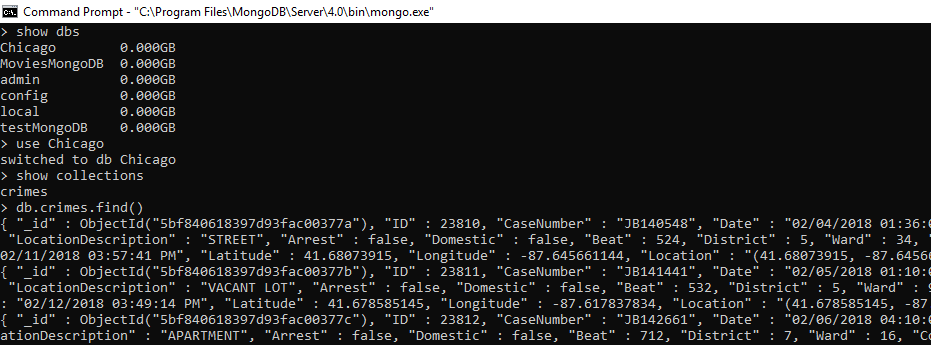

Mongo Tutorial Image

With the success of the tutorial, close the connection.

```r
#Close the connection to the mongoDB
mongo.destroy(mongo)
```

```r
print(mongo.is.connected(mongo))
```

```
## [1] FALSE
```

```r
#create a connection to the SQLite database
conn<- dbConnect(RMySQL::MySQL(),
                  dbname="movie_reviews",
                  host="DESKTOP-FGDMVA4",
                  user="Student01",
                  password="CUNY_DATA607"
                  )
```

#### Printout list of tables in the connection

```r
dbListTables(conn)
```

```
## [1] "movies"    "reviewers" "reviews"
```

### 3. Migrate the data from the Movies database into MonogoDB

MW Frost code for migrating a R dataframe to MongoDB.

[R function migrates code to MongoDB](https://gist.github.com/mwfrost/6385201)

```r
#The parameters take in a dataframe, the name of the Mongo DB, the name of the collection and the variable names of a dataframe
convert_Movies_df <- function(df, db='MoviesMongoDB', col='moviescollection', fields=names(df)) {
#Create a connection
    mongo <- mongo.create(host = "localhost")
  if (mongo.is.connected(mongo)) {
#Iterates over each row of the dataframe and converts it to bson object which is then inserted into the Mongo instance.
    for(i in 1:nrow(df)) {
        b <- mongo.bson.from.list(df[i,fields])
        if (!is.null(b)){
          mongo.insert(mongo, paste(db, col, sep='.'), b)
          #print("loaded")
          }
        else {
          print('NULL BSON object')
          print(t(df[i,]))
              }
      }
  }
}
```

Apply the function to each dataframe

```r
convert_Movies_df(Movies)
convert_Movies_df(Reviews)
convert_Movies_df(Reviewers)
```

```r
movies_collection = mongo(collection = 'moviescollection', db='MoviesMongoDB')
movies_collection$info()
```

[output not shown]

```r
movies_collection$count()
```

```
## [1] 138
```

```r
nrow(Reviews) + nrow(Reviewers) + nrow(Movies)
```

```
## [1] 69
```

```r
movies_collection$iterate()$one()
```

```
## $ID
## [1] 1
##
## $Title
## [1] "Avengers Infinity Wars"
##
## $Genre
## [1] "Super Hero Action"
##
## $Box_Office
## [1] 2.046e+09
##
## $Male_Lead
## [1] "Robert Downey Jr"
##
## $Female_Lead
## [1] "Scarlett johansson"
##
## $Length
## [1] "02:29:00"
##
## $Trailer
## [1] "https://www.youtube.com/watch?v=Xe5MeKNFjGQ"
```

A screen shot from the Mongo instance also shows that the data has been migrated:

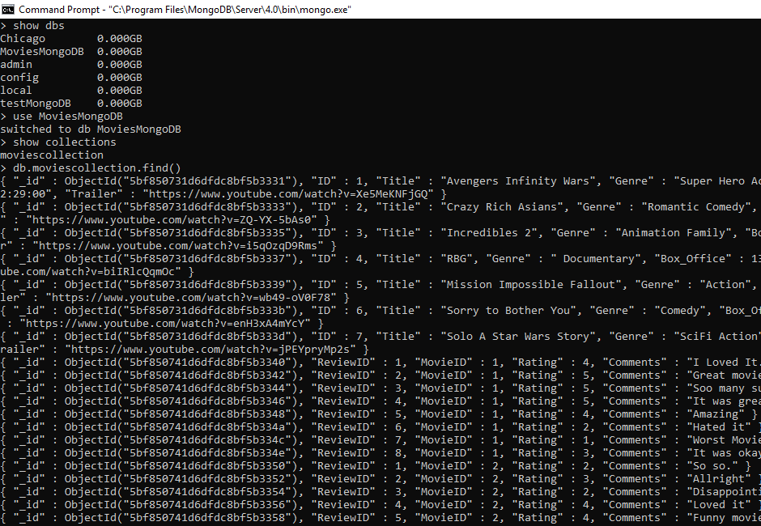

Mongo Movies

### 4. Final reflections

I found this to be one of the more challenging assignments of the semester. I am very intrigued about Graph databases and NoSQL databases as this will become the standard database in my field of E-Discovery. As data grows larger and sources become more diverse, traditional relational databases may not be adquate.

Finally, I was not able to get the “mongo.get.database.collections” function to work properly, and I cannot figure it out.

```r
mongo_new <- mongo.create(host = "localhost", db='MoviesMongoDB')
mongo.is.connected(mongo_new)
```

```
## [1] TRUE
```

```r
mongo.get.database.collections(mongo_new, db='MoviesMongoDB')
```

```
## character(0)
```